# Week 1

Chris Beeley

11/02/2021

## Chapter 2

### E1

Probability of rain on Monday would be written as Pr(Rain | Monday)

### E2

Pr(Monday | Rain) means the probability of Monday given that it is raining

### E3

The probability that it is Monday given that it is raining would be written Pr(Monday | Rain)

### E4

Bruno de Finetti wrote PROBABILITY DOES NOT EXIST which is of course quite true. Everything that happened, happened, and everything that didn’t happen, didn’t happen. However probability expresses a truth about reality in the sense that if you spin a globe and point to a random part of it, and repeat this observation, the average frequency of water will approach 0.7 at infinity. A similar process describes radioactive decay. So probability is false when it is used to describe events, but true when it describes processes, especially processes that are repeated.

### M1

Compute and plot the grid approximation for the globe tossing experiment (randomly sampling water and land)

Plot- W, W, W

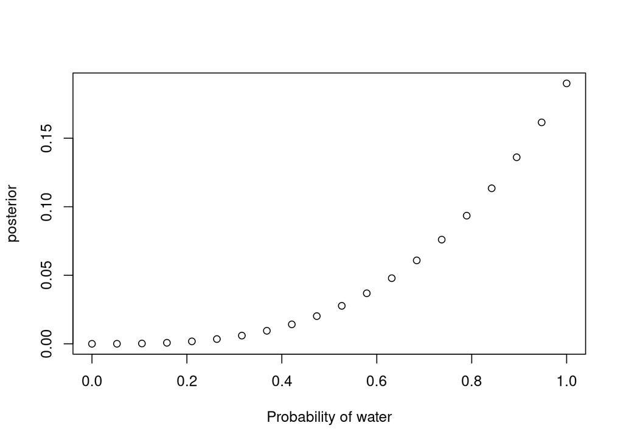

```r
p_grid <- seq(0, 1, length.out = 20)

prior <- rep(1, 20)

likelihood <- dbinom(3, size = 3, prob = p_grid)

unstd.posterior <- likelihood * prior

posterior <- unstd.posterior / sum(unstd.posterior)

plot(p_grid, posterior, xlab = "Probability of water")
```

```r
# produce a function

grid_approximation <- function(water, trials){

  p_grid <- seq(0, 1, length.out = 20)

  prior <- rep(1, 20)

  likelihood <- dbinom(water, size = trials, prob = p_grid)

  unstd.posterior <- likelihood * prior

  posterior <- unstd.posterior / sum(unstd.posterior)

  plot(p_grid, posterior, xlab = "Probability of water")
}
```

Plot L, W, W, L, W, W, W

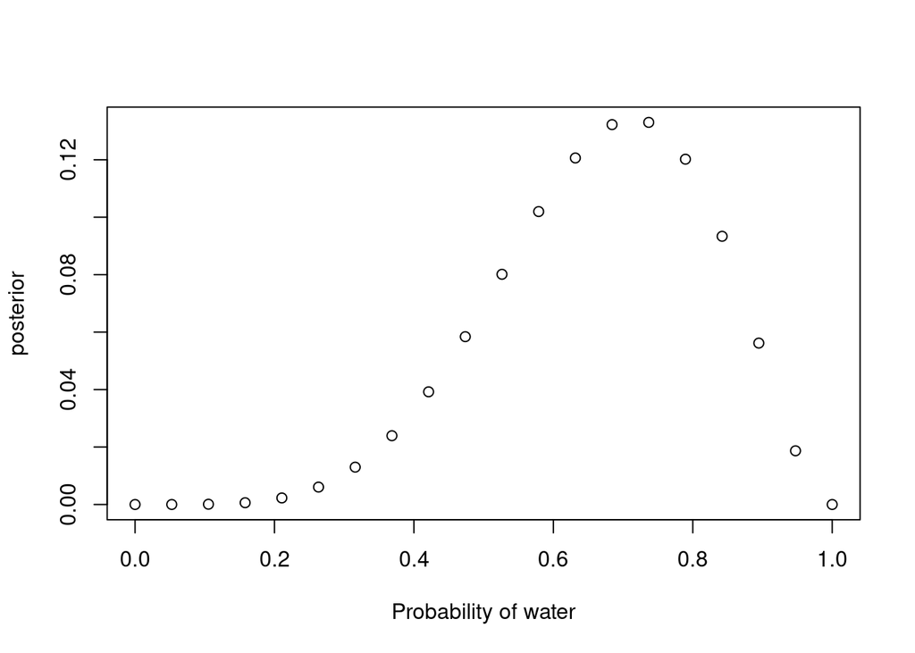

```r
grid_approximation(5, 7)
```

### M2

Now assume a prior of zero when p < .5 and a constant when p >= 0.5, and compute the above again.

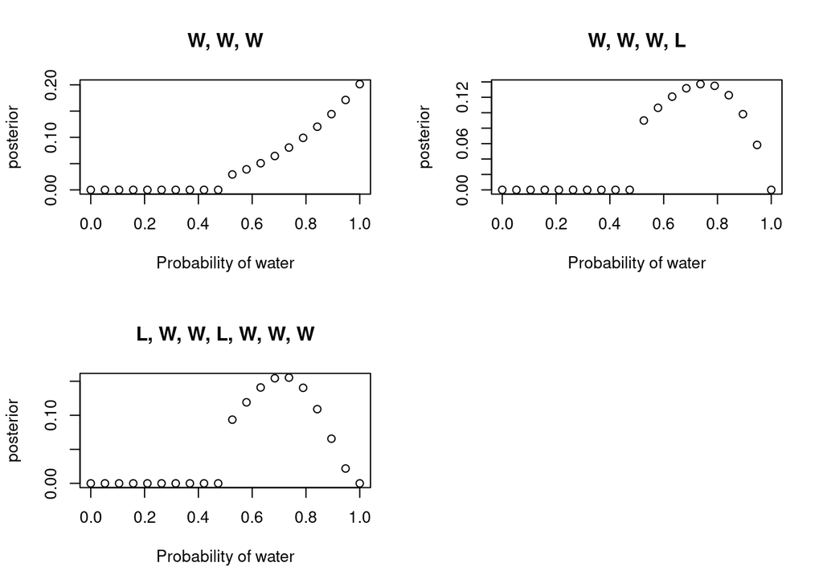

```r
# produce a function

grid_approximation_prior <- function(water, trials, title){

  p_grid <- seq(0, 1, length.out = 20)

  prior_f <- ifelse(p_grid < .5, 0, 1)

  likelihood <- dbinom(water, size = trials, prob = p_grid)

  unstd.posterior <- likelihood * prior_f

  posterior <- unstd.posterior / sum(unstd.posterior)

  plot(p_grid, posterior, xlab = "Probability of water",
       main = title)
}

par(mfrow = c(2, 2))

grid_approximation_prior(3, 3, "W, W, W")
grid_approximation_prior(3, 4, "W, W, W, L")
grid_approximation_prior(5, 7, "L, W, W, L, W, W, W")

par(mfrow = c(1, 1))
```

### M3

Assume there are two globes. Mars is 100% land, Earth is 30% land. One is sampled and produces a “land” observation. Assume they are equally likely to be sampled. Show that Pr(Earth | Land) is 0.23.

$$p(A|B) = \frac{p(B | A) . p(A)}{p(B)}$$

$$p(Earth | Land) = \frac{p(Land | Earth) . p(Earth)}{p(Land)}$$

$$p(Earth | Land) = \frac{0.3 * 0.5}{0.65}$$

$$p(Earth | Land) = .23$$

### M4

Suppose you have 3 cards. One is black on one side and white on the other, one is WW, and one is BB. If you turn over a card and one side is black show that p(other side is black) = $\frac{2}{3}$

Counting method:

| WW | W | \| |
| --- | --- | --- |
|  | W | \| |
| BW | B | -> W |
|  | W | \| |
| BB | B | -> B |
|  | B | -> B |

In the second column we see the possibilities that exist for a black side- there are 3. In the third column we see of these two possibilities only 2 lead to black on the other side. Therefore, the probability is $\frac{2}{3}$

### H1

$$p(A|B) = \frac{p(B | A) . p(A)}{p(B)}$$

$$p(Species A | Twins) = \frac{p(Twins | Species A) . p(Species A)}{p(Twins)}$$

$$p(Species A | Twins) = \frac{p(.1) . p(.5)}{p(.15)}$$

$$p(Species A | Twins) = \frac{1}{3}$$

## Chapter 3

### E 1-6

This is using the globe tossing example again, the code below is in the book to help

```r
p_grid <- seq(0, 1, length.out = 1000)
prior <- rep(1, 1000)
likelihood <- dbinom(6, 9, prob = p_grid)

posterior <- likelihood * prior
posterior <- posterior / sum(posterior)

set.seed(100)
samples <- sample(p_grid, prob = posterior, size = 1e4, replace = TRUE)
```

E1. How much posterior probability lies below .2?

```r
mean(samples < .2)
```

```
## [1] 4e-04
```

E2. How much posterior probability lies above .8?

```r
mean(samples > .8)
```

```
## [1] 0.1116
```

E4. 20% of the posterior probability lies below what value of p?

```r
sort(samples)[length(samples) * .2]
```

```
## [1] 0.5185185
```

### E6. Which values of p contain the narrowest interval equal to 66% of the posterior probability?

```r
rethinking::HPDI(samples, prob = .66)
```

```
##     |0.66     0.66|
## 0.5085085 0.7737738
```

### M1

Construct the globe tossing example again, with 8 water in 15 tosses. Construct the posterior distribution with a grid approximation.

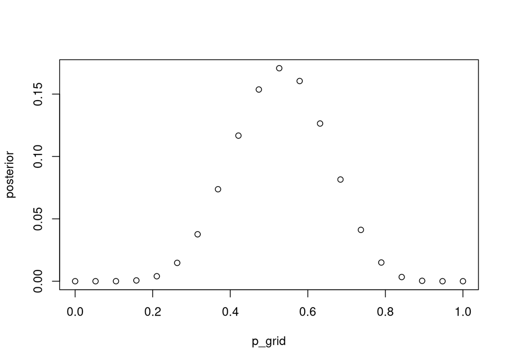

```r
p_grid <- seq(0, 1, length.out = 20)

prior <- rep(1, 20)

likelihood <- dbinom(8, size = 15, prob = p_grid)

unstd.posterior <- likelihood * prior

posterior <- unstd.posterior / sum(unstd.posterior)

plot(p_grid, posterior)
```

### M2

Draw 1e4 samples from the grid approximation. Then calculate the 90% Highest Posterior Density Interval (HPDI).

```r
set.seed(100)
samples <- sample(p_grid, prob = posterior, size = 1e4, replace = TRUE)

rethinking::HPDI(samples, .9)
```

```
##      |0.9      0.9|
## 0.3157895 0.6842105
```

### M3

Construct a posterior predictive check for this model and data. This means simulate the distribution of samples, averaging over the posterior uncertainty in p. What is probability of observing 8 water in 15 tosses?

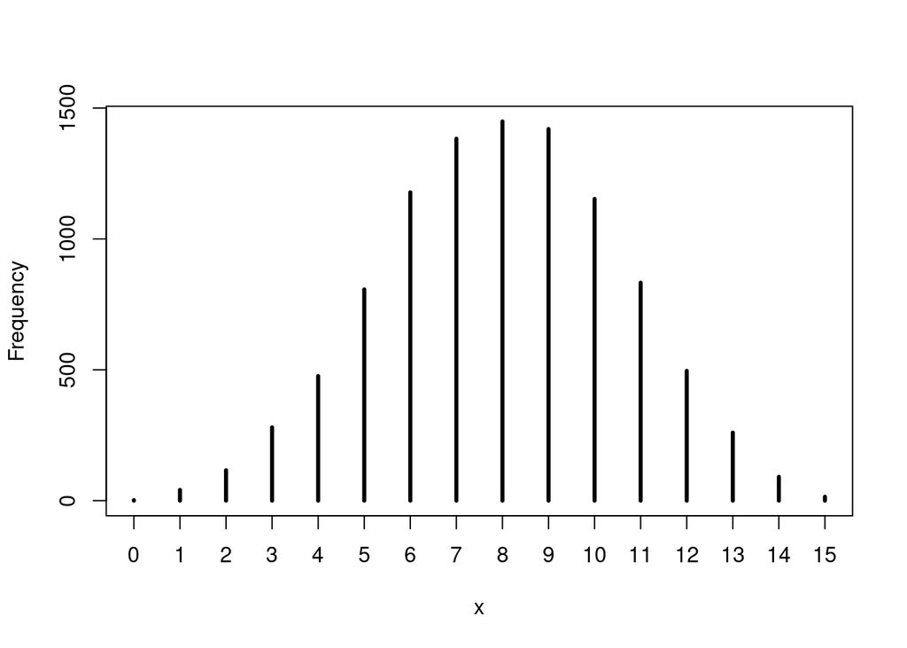

```r
ppc <- rbinom(1e4, size = 15, prob = samples)

rethinking::simplehist(ppc)
```

```r
sum(ppc == 8) / sum(ppc %in% c(0 : 7, 9 : 15))
```

```
## [1] 0.1694539
```